# Ch 7 exercises

The aim of these exercises is to make sure you’re comfortable with fitting factorial linear models to data

For each of the examples below, you should follow the sequence we’ve used previously:

| What is the biological question? |
| --- |
| Are the predictors continuous or categorical? |
| Write out the linear model corresponding to this question. |
| What distribution do you expect the response variable to follow? |
| What are the assumptions behind the statistical model you’ll fit? |
| Are those assumptions satisfied? |
| **Fit the model** |
| How will you assess whether the model fits well? Can you detect an effect of the predictor? How do you measure the effect? |
| What next steps would you suggest? |
| What do you conclude (including any cautions) |

1. What is the biological question?
2. Are the predictors continuous or categorical?
3. Write out the linear model corresponding to this question.
4. What distribution do you expect the response variable to follow?
5. What are the assumptions behind the statistical model you’ll fit? Are those assumptions satisfied?
6. Fit the model

   How will you assess whether the model fits well? Can you detect an effect of the predictor? How do you measure the effect?
7. What next steps would you suggest?
8. What do you conclude (including any cautions)

### A

Hostetler et al. (2016) examined the effects of methamphetamine (MA) on hypothalamic neuropeptides in the brains of laboratory-housed prairie voles. Individual voles were the experimental units, and there were two fixed factors. Treatment, representing access to MA or water, was an experimental factor, crossed with sex (male vs. female), an observational factor, with five or six voles in each of the four combinations.

**Hint**. To help you analyse this data set in R, have a look at the online version of Box 7.3, which includes some relevant R code.

We’ll start with the oxytocin data as the response variable.

| What is the biological question? | Does MA (at the chosen concentration) affect levels of neuropeptides? Are there differences between males and females in overall neuropeptide levels? Does the response to MA differ between sexes? |
| --- | --- |
| Are the predictors continuous or categorical? | Categorical |
| Write out the linear model corresponding to this question. | NP = constant + MA + Sex + MA x Sex |
| What distribution do you expect the response variable to follow? | Not our field, so we’re not sure at the start, but we’ll assume for now normal |
| What are the assumptions behind the statistical model you’ll fit? | Normality or other specified distribution for error terms Variances homogeneous between factor combinations Observations are independent of each other (e.g. voles housed singly) |
| Are those assumptions satisfied? | We’re only guessing at this stage for the first two. The third needs a careful read of the methods section of the paper. |
| Fit the model | Fit OLS model (Type I SS) to untransformed data |

#### Now’s a good time to get the data and load some packages

```r
library(tidyverse)
library (car) # We can make do with this one to start with
library(emmeans)
```

Import hostetler_OT data file (hostetler OT.csv)

```r
host_ot <- read.csv("data/hostetler OT.csv")
head(host_ot,10)
```

|  | Animal.ID | trtmt | sex | pvn1 | pvn2 | pvn3 | pvn4 | pvn5 | pvn6 | otmean |
| --- | --- | --- | --- | --- | --- | --- | --- | --- | --- | --- |
| 1 | 231.15-5 | 0 | 1 | 35 | 32 | 56 | 51 | NA | NA | 43.5 |
| 2 | 220.17-2 | 1 | 1 | 39 | 44 | 41 | 29 | 34 | 27 | 35.7 |
| 3 | 248.1-4 | 0 | 1 | 39 | 30 | 55 | 34 | 80 | 73 | 51.8 |
| 4 | 240.7-4 | 1 | 1 | 26 | 26 | 70 | 56 | NA | NA | 44.5 |
| 5 | 220.17-4 | 0 | 1 | 48 | 55 | 68 | 70 | NA | NA | 60.3 |
| 6 | 231.15-6 | 1 | 1 | 66 | 51 | 38 | 52 | 50 | 39 | 49.3 |
| 7 | 220.17-5 | 0 | 1 | 57 | 59 | 59 | 47 | NA | NA | 55.5 |
| 8 | 240.7-3 | 1 | 1 | 25 | 29 | 39 | 37 | 35 | 31 | 32.7 |
| 9 | 232.17-2 | 0 | 1 | 42 | 57 | NA | NA | NA | NA | 49.5 |
| 10 | 220.17-3 | 1 | 1 | 43 | 56 | 59 | 83 | NA | NA | 60.3 |

```r
# make sex & trtmt factors
host_ot$sex<-as.factor(host_ot$sex)
host_ot$trtmt<-as.factor(host_ot$trtmt)
```

** Examine boxplots by cell**

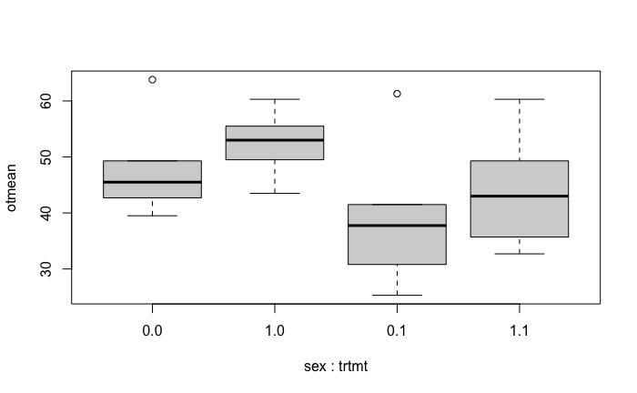

```r
boxplot(otmean~sex*trtmt,data=host_ot)
```

> No particular issues here, so happy to proceed. Remember that boxplots aren’t necessarily informative with small sample sizes

```r
host.aov <- aov(otmean~sex*trtmt, data=host_ot)
summary(host.aov)
```

```
            Df Sum Sq Mean Sq F value Pr(>F)
sex          1    145     145    1.54  0.229
trtmt        1    440     440    4.67  0.044 *
sex:trtmt    1      1       1    0.01  0.939
Residuals   19   1790      94
---
Signif. codes:  0 ‘***’ 0.001 ‘**’ 0.01 ‘*’ 0.05 ‘.’ 0.1 ‘ ’ 1
```

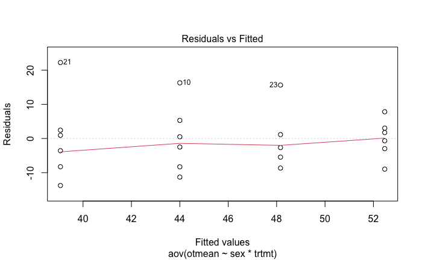

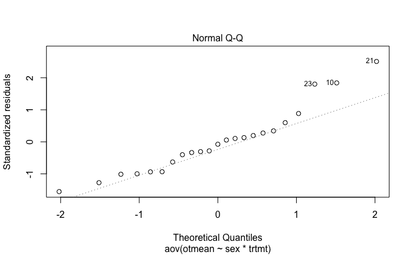

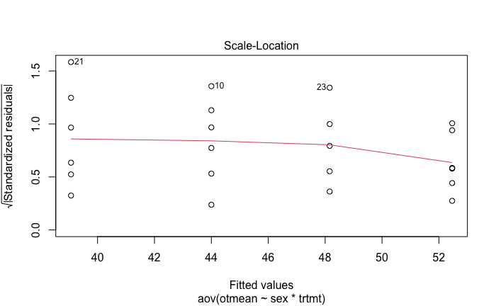

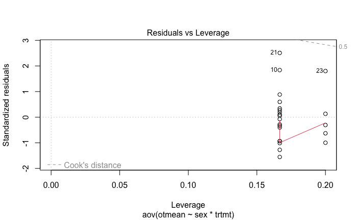

```r
plot(host.aov)
```

| How will you assess whether the model fits well? Can you detect an effect of the predictor? How do you measure the effect? | Do a check of residual plots. No particular issues Look at r<sup>2</sup> Do ANOVA Generate estimates of means/effects along with CIs |
| --- | --- |

```
How will you assess whether the model fits well?

Can you detect an effect of the predictor?
```

> Run anova with Type III SS

#### Now get Type II and Type III SS using car package

```r
host.lm1 <- lm(otmean~trtmt*sex, data=host_ot, contrasts=list(trtmt=contr.sum, sex=contr.sum))
Anova(host.lm1, type='III')
```

```
Anova Table (Type III tests)

Response: otmean
            Sum Sq Df F value  Pr(>F)
(Intercept)  48205  1  511.80 3.4e-15 ***
trtmt          441  1    4.68   0.044 *
sex            122  1    1.29   0.269
trtmt:sex        1  1    0.01   0.939
Residuals     1790 19
---
Signif. codes:  0 ‘***’ 0.001 ‘**’ 0.01 ‘*’ 0.05 ‘.’ 0.1 ‘ ’ 1
```

```
How do you measure the effect?
```

> Generate cell means, CIs etc.

```r
emmeans(host.lm1, ~ trtmt:sex)
```

```
 trtmt sex emmean   SE df lower.CL upper.CL
 0     0     48.2 4.34 19     39.1     57.2
 1     0     39.1 3.96 19     30.8     47.4
 0     1     52.5 3.96 19     44.2     60.8
 1     1     44.0 3.96 19     35.7     52.3

Confidence level used: 0.95
```

```
dv column detected: otmean
No id column passed. Assuming all rows are independent samples.
```

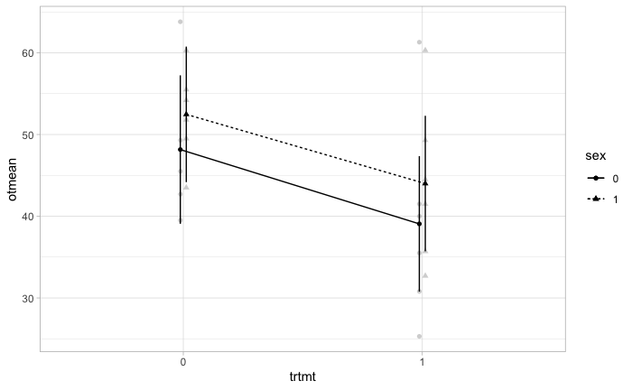

```r
afex_plot(host.lm1, "trtmt", "sex", dodge=0.05)+theme_light()
```

```r
emmeans(host.lm1, ~ trtmt)
```

```
NOTE: Results may be misleading due to involvement in interactions
```

```
 trtmt emmean   SE df lower.CL upper.CL
 0       50.3 2.94 19     44.2     56.5
 1       41.5 2.80 19     35.7     47.4

Results are averaged over the levels of: sex
Confidence level used: 0.95
```

| What next steps would you suggest? | Nothing much - there’s no interaction, and each factor has only 2 levels. We can interpret the results from here It’s only MA having an effect here, so we could just summarize by MA |
| --- | --- |
| What do you conclude (including any cautions) | No red flags in the data, so we’re pretty happy. MA causes a 15-20% drop in Oxytocin levels, and the response is independent of sex of voles. |

**Would the same approach work for AVT?**

> The important step is looking at these data with box and residual plots; our question is about the distribution of the response variable

```r
host_avp <- read.csv("data/hostetler AVP.csv")
head(host_ot,10)
```

|  | Animal.ID | trtmt | sex | pvn1 | pvn2 | pvn3 | pvn4 | pvn5 | pvn6 | otmean |
| --- | --- | --- | --- | --- | --- | --- | --- | --- | --- | --- |
| 1 | 231.15-5 | 0 | 1 | 35 | 32 | 56 | 51 | NA | NA | 43.5 |
| 2 | 220.17-2 | 1 | 1 | 39 | 44 | 41 | 29 | 34 | 27 | 35.7 |
| 3 | 248.1-4 | 0 | 1 | 39 | 30 | 55 | 34 | 80 | 73 | 51.8 |
| 4 | 240.7-4 | 1 | 1 | 26 | 26 | 70 | 56 | NA | NA | 44.5 |
| 5 | 220.17-4 | 0 | 1 | 48 | 55 | 68 | 70 | NA | NA | 60.3 |
| 6 | 231.15-6 | 1 | 1 | 66 | 51 | 38 | 52 | 50 | 39 | 49.3 |
| 7 | 220.17-5 | 0 | 1 | 57 | 59 | 59 | 47 | NA | NA | 55.5 |
| 8 | 240.7-3 | 1 | 1 | 25 | 29 | 39 | 37 | 35 | 31 | 32.7 |
| 9 | 232.17-2 | 0 | 1 | 42 | 57 | NA | NA | NA | NA | 49.5 |
| 10 | 220.17-3 | 1 | 1 | 43 | 56 | 59 | 83 | NA | NA | 60.3 |

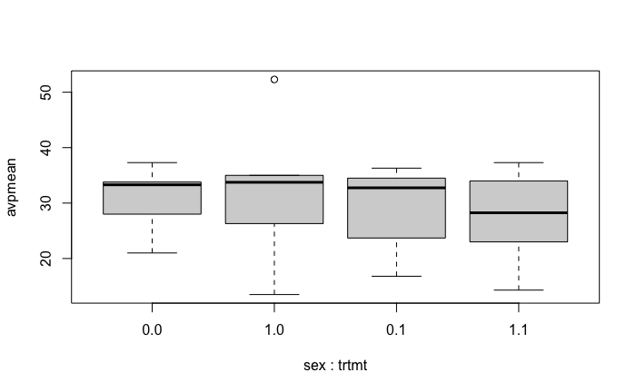

```r
# make sex & trtmt factors
host_avp$sex<-as.factor(host_avp$sex)
host_avp$trtmt<-as.factor(host_avp$trtmt)
boxplot(avpmean~sex*trtmt,data=host_avp)
```

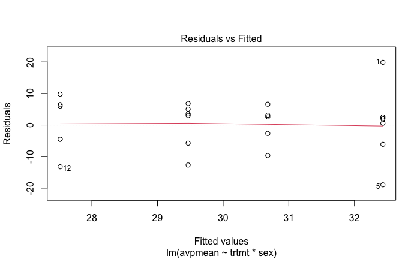

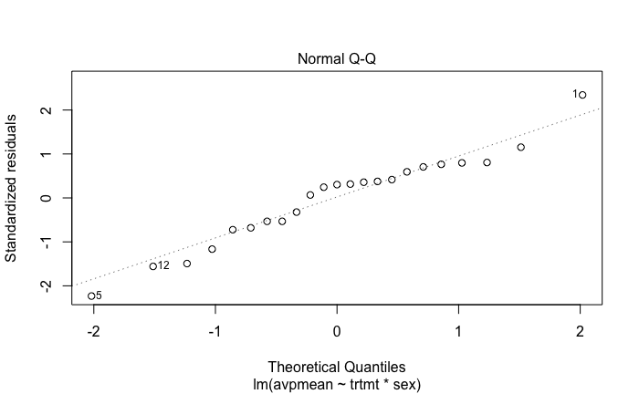

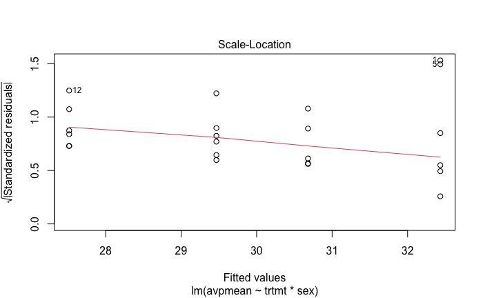

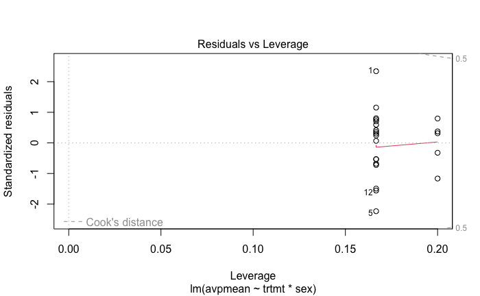

```r
host.lm2 <- lm(avpmean~trtmt*sex, data=host_avp, contrasts=list(trtmt=contr.sum, sex=contr.sum))
plot(host.lm2)
```

```r
Anova(host.lm2, type='III')
```

```
Anova Table (Type III tests)

Response: avpmean
            Sum Sq Df F value  Pr(>F)
(Intercept)  20605  1  238.75 3.3e-12 ***
trtmt           54  1    0.62    0.44
sex              0  1    0.00    0.98
trtmt:sex       20  1    0.23    0.64
Residuals     1640 19
---
Signif. codes:  0 ‘***’ 0.001 ‘**’ 0.01 ‘*’ 0.05 ‘.’ 0.1 ‘ ’ 1
```

> Some weak indication of skew in boxplots, but residuals don’t show much, so we’ll be satisfied with normality assumption. Same model should work in this case (and it doesn’t suggest any particular strong effects)

### B

[Kraskura et al (2021)](https://doi.org/10.1093/conphys/coab016) examined sex-specific differences in the metabolic responses of coho salmon (*Oncorhynchus kisutch*) to three different temperatures: 9°C (typical), 14°C (current maximum) and 18°C (climate change scenario). Fish were collected from a hatchery in British Columbia, Canada, and returned to a research laboratory and held in outdoor tanks at 9°C. Temperatures were raised slowly to the relevant test temperature and held for 2 days. Fish were then transferred individually to a swim tunnel respirometer where critical swim speed was measured by increasing the water velocity until the fish could no longer maintain its position in the water column. In addition, the maximum metabolic rate was also recorded during each trial. The fish were subsequently euthanized and their sex determined.

**Analyze these data to examine the effects of temperature, sex and the interaction between these two fixed factors on absolute critical swim speed (cm s<sup>-1</sup>).**

The data are available on [Dryad](https://doi.org/10.25349/D9390K). They are in an Excel document that needs some tidying before using in R, as sheets with data include columns for summary statistics, etc. A tidied version is here

> The code for the Hostetler example will be a good starting point. We’ll just show the output as a block including EDA and the analysis. The pplot is the only thing, with some non-linearity at one end, but prob not enough to be a concern

```r
krask <- read.csv("data/krask_swim.csv")
head(krask,10)
```

|  | fish_id | sex | temperature | bm_test_kg | ucrit_bl_s | ucrit_cm_s |
| --- | --- | --- | --- | --- | --- | --- |
| 1 | Oct06fish1 | F | 9 | 2.46 | 2.84 | 168 |
| 2 | Oct07fish2 | F | 9 | 1.52 | 2.49 | 114 |
| 3 | Oct08fish1 | F | 9 | 1.89 | 3.59 | 135 |
| 4 | Oct09fish1 | F | 9 | 1.61 | 3.18 | 113 |
| 5 | Oct10fish2 | F | 9 | 1.98 | 3.65 | 155 |
| 6 | Oct14fish1 | F | 9 | 2.14 | 3.13 | 161 |
| 7 | Oct14fish2 | F | 9 | 2.03 | 2.77 | 106 |
| 8 | Oct16fish1 | F | 9 | 2.58 | 2.94 | 168 |
| 9 | Oct16fish2 | F | 9 | 2.71 | 2.64 | 141 |
| 10 | Oct16fish3 | F | 9 | 3.25 | 3.09 | 155 |

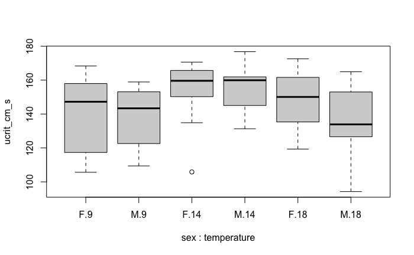

```r
# make sex & temperature factors
krask$sex<-as.factor(krask$sex)
krask$temperature<-as.factor(krask$temperature)
boxplot(ucrit_cm_s~sex*temperature,data=krask)  #Two ucrit variables, one as body lengths/s, the other cm
```

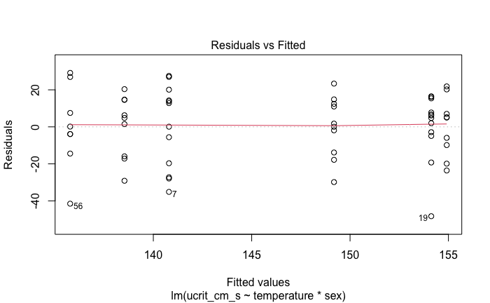

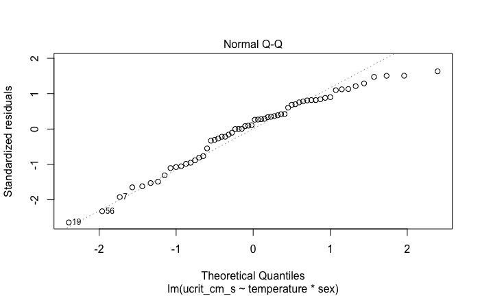

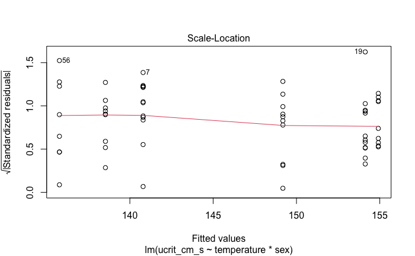

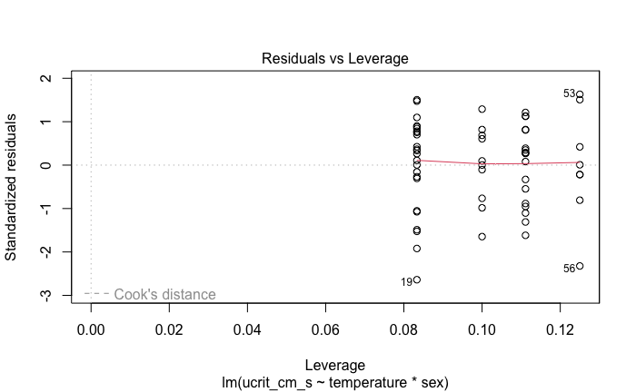

```r
krask.lm <- lm(ucrit_cm_s~temperature*sex, data=krask, contrasts=list(temperature=contr.sum, sex=contr.sum))
plot(krask.lm)
```

```r
Anova(krask.lm, type='III')
```

```
Anova Table (Type III tests)

Response: ucrit_cm_s
                 Sum Sq Df F value Pr(>F)
(Intercept)     1242404  1 3403.18 <2e-16 ***
temperature        2534  2    3.47  0.038 *
sex                 361  1    0.99  0.324
temperature:sex     522  2    0.72  0.494
Residuals         19714 54
---
Signif. codes:  0 ‘***’ 0.001 ‘**’ 0.01 ‘*’ 0.05 ‘.’ 0.1 ‘ ’ 1
```

```r
emmeans(krask.lm, ~ temperature:sex)
```

```
 temperature sex emmean   SE df lower.CL upper.CL
 9           F      141 5.52 54      130      152
 14          F      154 5.52 54      143      165
 18          F      149 6.04 54      137      161
 9           M      138 6.37 54      126      151
 14          M      155 6.37 54      142      168
 18          M      136 6.76 54      122      149

Confidence level used: 0.95
```

**Would the same approach work for the Total Excess Post-Exercise Oxygen Consumption in mg O2/kg during chase respirometry trial response?**

The tidied metabolic rates file is here; the variable we’re interested in is total_epoc

> Boxplots and residual plots to decide. Evidence of variance heterogeneity and skew. Useful discussion about possible transforms (sqrt or log) or running glm (though not expected to be familiar with this approach).

```r
krask <- read.csv("data/krask_metab.csv")
head(krask,10)
```

|  | fish_id | sex | temperature | bm_test_kg | fl_test_cm | mmr | rmr | AAS | FAS | total_epoc |
| --- | --- | --- | --- | --- | --- | --- | --- | --- | --- | --- |
| 1 | 10_16_b1_1 | F | 9 | 1.63 | 52.7 | 12.16 | 1.380 | 10.78 | 8.81 | 512 |
| 2 | 10_16_b1_2 | F | 9 | 2.10 | 41.1 | 11.98 | 1.127 | 10.85 | 10.63 | 617 |
| 3 | 10_16_b1_3 | F | 9 | 1.62 | 55.0 | 9.75 | 1.099 | 8.65 | 8.87 | 367 |
| 4 | 10_16_b2_3 | F | 9 | 2.61 | 59.6 | 8.84 | 1.280 | 7.56 | 6.91 | 388 |
| 5 | 10_22_b1_1 | F | 9 | 2.54 | 60.8 | 11.92 | 1.262 | 10.65 | 9.44 | 612 |
| 6 | 10_22_b1_2 | F | 9 | 2.54 | 59.3 | 11.50 | 1.080 | 10.42 | 10.65 | 691 |
| 7 | 10_22_b2_1 | F | 9 | 2.56 | 60.1 | 13.60 | 0.989 | 12.61 | 13.75 | 485 |
| 8 | 10_22_b2_3 | F | 9 | 2.74 | 61.7 | 14.83 | 1.368 | 13.46 | 10.84 | 2783 |
| 9 | 10_30_b1_1 | F | 9 | 2.17 | 57.8 | 10.10 | 1.225 | 8.88 | 8.24 | 699 |
| 10 | 10_30_b1_2 | F | 9 | 2.31 | 58.4 | 7.84 | 1.308 | 6.53 | 5.99 | 623 |

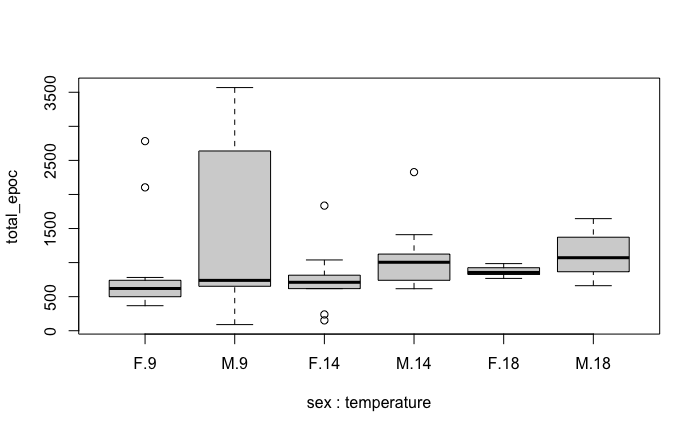

```r
# make sex & temperature factors
krask$sex<-as.factor(krask$sex)
krask$temperature<-as.factor(krask$temperature)
boxplot(total_epoc~sex*temperature,data=krask)  #Two metabolic rate variables, one max (mmr), the other resting (rmr)
```

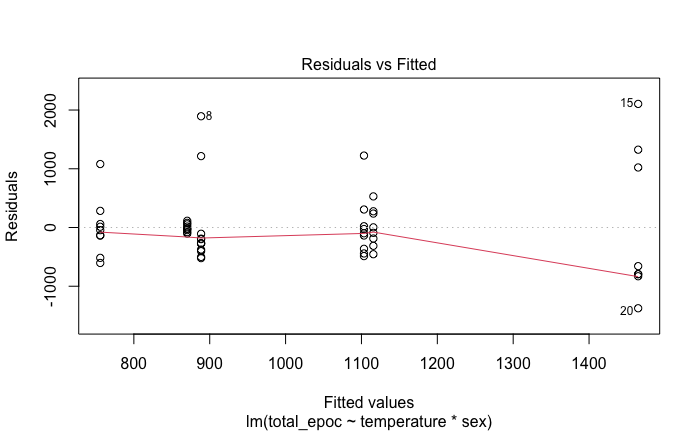

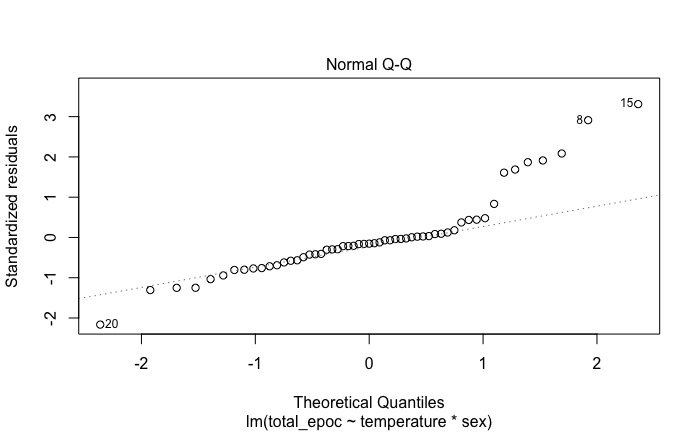

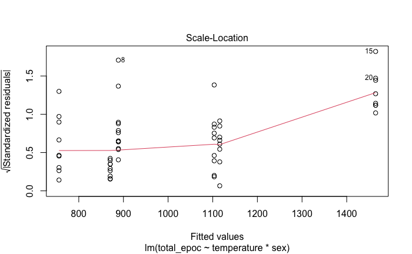

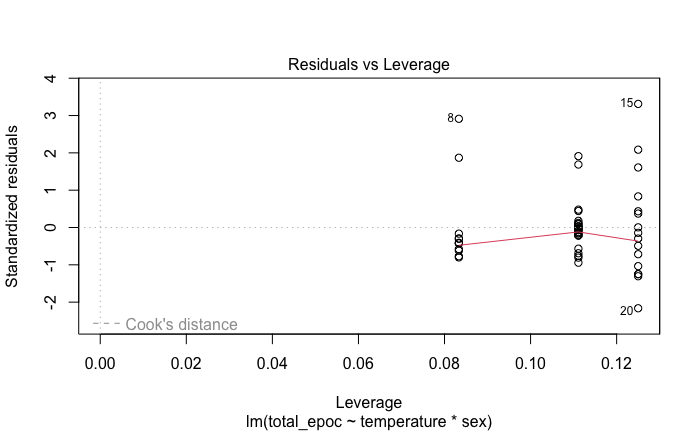

```r
krask.lm <- lm(total_epoc~temperature*sex, data=krask, contrasts=list(temperature=contr.sum, sex=contr.sum))
plot(krask.lm)
```

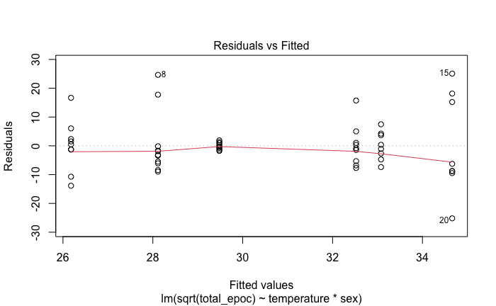

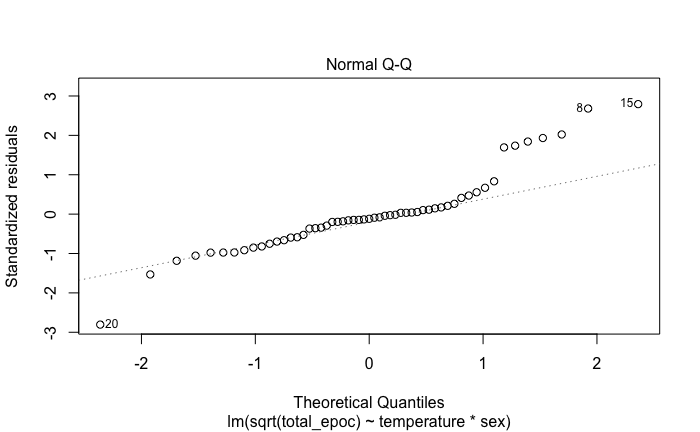

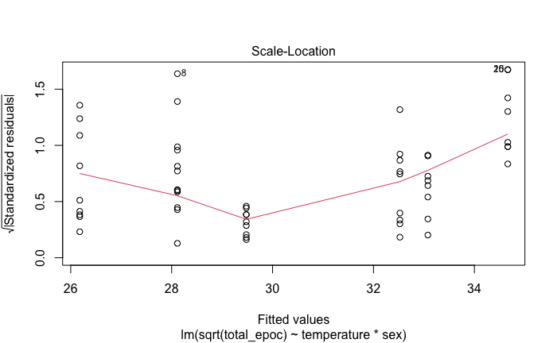

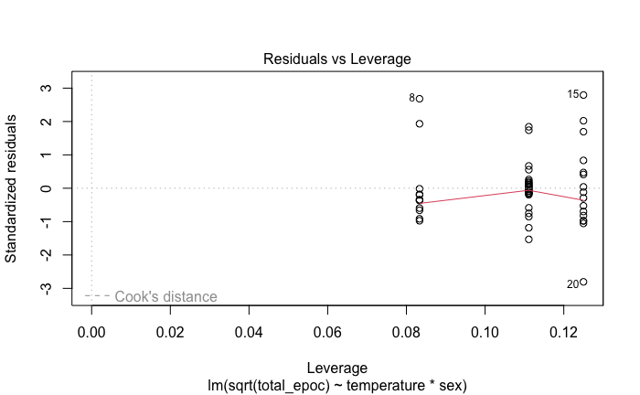

```r
krask.lm2 <- lm(sqrt(total_epoc)~temperature*sex, data=krask, contrasts=list(temperature=contr.sum, sex=contr.sum))
plot(krask.lm2)
```

```r
Anova(krask.lm2, type='III')
```

```
Anova Table (Type III tests)

Response: sqrt(total_epoc)
                Sum Sq Df F value Pr(>F)
(Intercept)      50803  1  551.62 <2e-16 ***
temperature         47  2    0.26   0.77
sex                408  1    4.43   0.04 *
temperature:sex     24  2    0.13   0.88
Residuals         4513 49
---
Signif. codes:  0 ‘***’ 0.001 ‘**’ 0.01 ‘*’ 0.05 ‘.’ 0.1 ‘ ’ 1
```

```
dv column detected: sqrt(total_epoc)
No id column passed. Assuming all rows are independent samples.
```

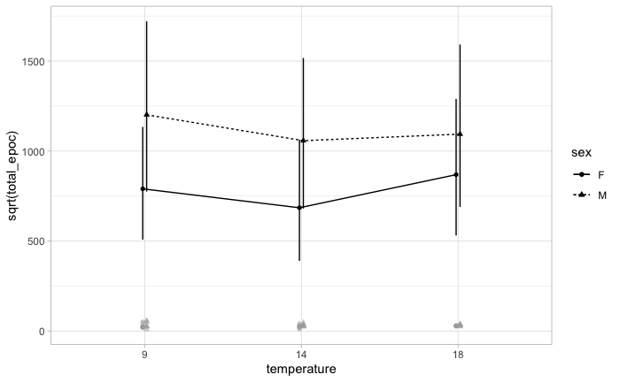

```r
afex_plot(krask.lm2, "temperature", "sex", dodge=0.05)+theme_light()
```

### C

This exercise is a little more complex, designed to start thinking about using additional predictors to give a clearer picture of any signals from predictors of interest, i.e. to reduce background noise in the data. Two things to note:

- We’ll assume you’ve completed the previous two exercises, so you’re familiar with multifactor models, the questions they answer, etc. We won’t go through the initial checklist again, but recommend that you do it anyway.
- We’ll come back to this example in exercises for later chapters (10, 11, and 13).

The example we’ll use is from Martello et al. (2022), who tested whether dietary supplements, which are often expensive, can help with symptoms of osteoarthritis in dogs. Their study was experimental, with 40 dogs with chronic pain symptoms. Dogs were also screened and excluded if, for example, they had recent surgery, were taking steroidal medication, etc. The dogs were then allocated randomly to one of two treatments, a dietary supplement that included glucosamine sulfate and chondroitin, and a placebo. The study was completely blind, so administration of treatments and recording of data was done with no knowledge of what each dog had received. The supplements were administered for 60 days, and dogs received treatments orally at 2g/10kg body weight. The treatments are the variable GROUP.

Two response variables were used, both involving scoring of dogs’ behaviour and activity:

1. Dog owners used a questionnaire, responses to which generated a value on a 40 point Helsinki Chronic Pain Index, and these assessments were done at the start of treatment, and after 40 and 60 days. In the data file, these measures are the variables HCPI, HCP.4 and HCP.6
2. Veterinary assessments were done at the same 3 times. These assessments were on a 5-point scale reflecting increasing degrees of lameness. These variables are SEGNI.OA.VET, SEGNI.OA.VET.4, SEGNI.OA.VET.6

We won’t deal with them here, but veterinarians also measured a range of physiological and biochemical variables from a blood sample at 0 and 60 days.

The authors stated that osteoarthritis is affected by a range of other factors, including sex, body weight, breed, etc., and they also considered whether other things like desexing, with its hormonal changes, might be important. They measured several other potential predictors:

- Sex
- Sterilization (Yes/No)
- Body weight (PESO.KG)
- Breed (RAZZA)
- Estimated age (ETA)
- Body condition score, which combines all of these to produce a 4-point scale (BCS).

The paper is: Martello, E., Bigliati, M., Adami, R., Biasibetti, E., Bisanzio, D., Meineri, G. & Bruni, N. (2022). Efficacy of a dietary supplement in dogs with osteoarthritis: A randomized placebo-controlled, double-blind clinical trial. PLoS One, 17, [e0263971](https://doi.org/10.1371/journal.pone.0263971), and the data are in the supporting information (and a copy is here).

The question of most interest is whether the dietary supplements result in an improvement after 60 days, and for now we’ll include sex in the analysis, as there are good grounds for expecting a range of sex-based differences.

Identify an appropriate model for examining whether the dog’s condition, as assessed by their owners, after 60 days, depends on whether a dog received the supplement or a placebo and whether those results depended on sex of the dog.

Before starting analysis, we’d do a little tidying up of the data file, to stay consistent with using lower-case for variable names and doing away with periods, etc. It doesn’t really matter, but it keeps things tidy. As we read in the data, we’ll also declare a few of the variables as factors. The code to tidy up the names is below as comments; we’ve already done that tidying to create the file we supply.

```r
df <- read.csv("data/martello.csv")
head(df,10)
```

|  | group | PAZIENTE | FAR | breed | wt | eta | ster | sex | REGIONE.ANATOMICA | Note | ESAMI.EMATICI | RX | bcs | hcp0 | hcp40 | hcp60 | vet0 | vet40 | vet60 | clin.BASELINE.MV.0 | clin.FUP.MV.2 | clin.FUP.MV.4 | clin.FUP.MV.6 | clin.BASELINE.PR.0 | clin.FUP.PR.2 | clin.FUP.PR.4 | clin.FUP.PR.6 |
| --- | --- | --- | --- | --- | --- | --- | --- | --- | --- | --- | --- | --- | --- | --- | --- | --- | --- | --- | --- | --- | --- | --- | --- | --- | --- | --- | --- |
| 1 | CTR | 21 | B | METICCIO | 21 | 10 | N | F | ANCA DX |  | NRM | SI | 3 | 25 | 25 | 25 | 2 | 2 | 2 | 1 | 1 | 1 | 2 | 1 | 1 | 1 | 1 |
| 2 | CTR | 22 | B | DOGUE DEB | 47 | 6 | N | M | GOMITI |  | NRM | SI | 3 | 26 | 26 | 28 | 2 | 2 | 2 | 1 | 1 | 1 | 2 | 1 | 1 | 1 | 1 |
| 3 | CTR | 23 | B | PASTORE T | 23 | 9 | N | M | GOMITO DX |  | NRM | SI | 2 | 32 | 32 | 30 | 3 | 3 | 3 | 2 | 1 | 2 | 2 | 2 | 0 | 1 | 2 |
| 4 | CTR | 24 | B | METICCIO | 32 | 8 | S | F | ANCA DX/SX |  | NRM | SI | 3 | 34 | 34 | 32 | 3 | 3 | 3 | 2 | 2 | 1 | 1 | 3 | 3 | 3 | 3 |
| 5 | CTR | 25 | B | METICCIO | 29 | 4 | N | M | GOMITO DX/SX |  | NRM | SI | 3 | 20 | 20 | 22 | 1 | 1 | 2 | 0 | 0 | 1 | 2 | 1 | 1 | 1 | 1 |
| 6 | CTR | 26 | B | METICCIO | 35 | 12 | N | M | ANCA DX/SX |  | NRM | SI | 4 | 26 | 26 | 28 | 2 | 2 | 2 | 1 | 1 | 1 | 2 | 1 | 1 | 1 | 1 |
| 7 | CTR | 27 | B | METICCIO | 30 | 8 | N | F | GOMITO DX | CARPO DX | NRM | SI | 4 | 28 | 28 | 28 | 2 | 2 | 2 | 1 | 1 | 1 | 1 | 1 | 0 | 0 | 1 |
| 8 | CTR | 28 | B | LABRADOR R | 28 | 11 | N | F | GINOCCHIO DX |  | NRM | SI | 3 | 22 | 22 | 20 | 1 | 1 | 1 | 0 | 0 | 1 | 1 | 0 | 1 | 0 | 0 |
| 9 | CTR | 29 | B | GOLDEN R | 24 | 7 | S | F | ANCA SX |  | NRM | SI | 3 | 38 | 28 | 28 | 3 | 3 | 2 | 0 | 0 | 1 | 2 | 1 | 1 | 0 | 0 |
| 10 | CTR | 30 | B | LAGOTTO | 18 | 9 | S | F | GINOCCHIO DX | TARSO DX | NRM | SI | 3 | 40 | 36 | 40 | 3 | 2 | 3 | 3 | 3 | 3 | 3 | 2 | 2 | 2 | 1 |

```r
#Tidy up the names
#df_names<-c(group="GROUP", ster="sterilizzato", bcs="BCS",eta="ETA", breed="RAZZA",
#                  hcp0="HCPI", hcp40="HCPI.4", hcp60="HCP.6",
#                  vet0="SEGNI.OA.VET", vet40="SEGNI.AO.VET.4", vet60="SEGNI.AO.VET.6")
#df<-rename(df, !!!df_names)
# make sex, treatment, and sterilization factors
df$sex<-as.factor(df$sex)
df$group<-as.factor(df$group)
df$ster<-as.factor(df$ster)
#set contrasts to sum
contrasts=list(group=contr.sum, sex=contr.sum, ster=contr.sum)
```

Start with boxplots, then fit model and look at residuals

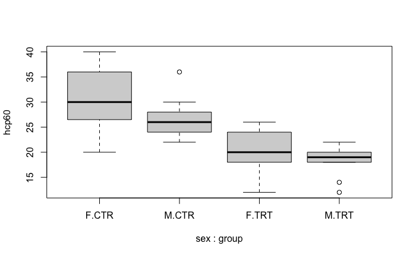

```r
boxplot(hcp60~sex*group,data=df)
```

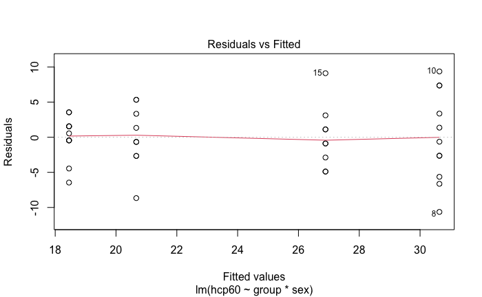

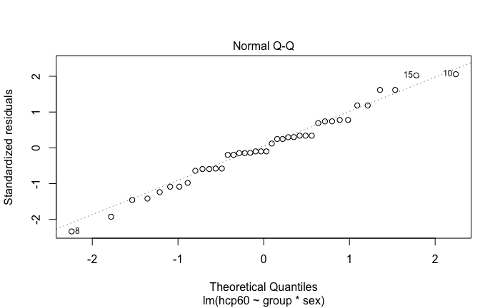

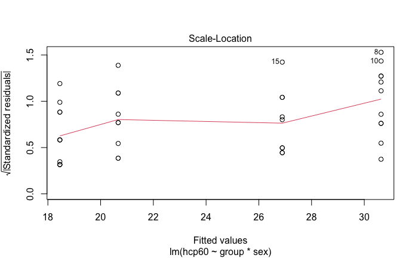

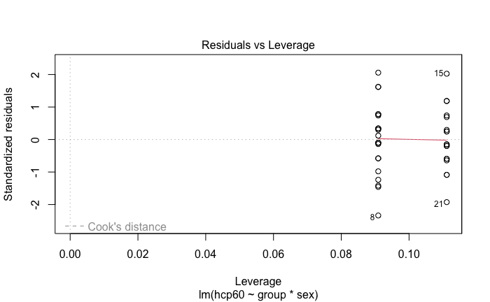

```r
martello.lm <- lm(hcp60~group*sex, data=df)
plot(martello.lm)
```